# Lab 4: Spatial Predictive Analysis

### 3. Distance-to-hotspot measures

```r
# Keep only hotspot cells
hotspots <- fishnet_counts |>
  filter(cluster_type == "High-High")

# Create centroids for all cells and hotspot cells
all_centroids <- st_centroid(fishnet_counts)
hotspot_centroids <- st_centroid(hotspots)

# Calculate distance to nearest hotspot
if (nrow(hotspots) > 0) {
  dist_matrix <- st_distance(all_centroids, hotspot_centroids)
  fishnet_counts$dist_to_hotspot <- apply(dist_matrix, 1, min) |> as.numeric()
} else {
  fishnet_counts$dist_to_hotspot <- NA_real_
}
```

```r
#summary table
distance_summary <- tibble(
  metric = c(
    "Minimum distance to hotspot",
    "Maximum distance to hotspot",
    "Mean distance to hotspot"
  ),
  value = c(
    round(min(fishnet_counts$dist_to_hotspot, na.rm = TRUE), 2),
    round(max(fishnet_counts$dist_to_hotspot, na.rm = TRUE), 2),
    round(mean(fishnet_counts$dist_to_hotspot, na.rm = TRUE), 2)
  )
)

kable(
  distance_summary,
  caption = "Summary of Distance to Nearest Hot Spot"
)
```

Summary of Distance to Nearest Hot Spot

| metric | value |
| --- | --- |
| Minimum distance to hotspot | 0.00 |
| Maximum distance to hotspot | 14115.59 |
| Mean distance to hotspot | 3791.57 |

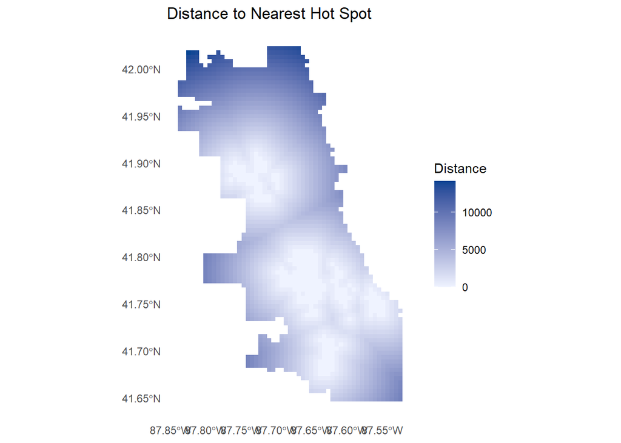

```r
ggplot(fishnet_counts) +
  geom_sf(aes(fill = dist_to_hotspot), color = NA) +
  scale_fill_gradient(
    low = "#eff3ff",
    high = "#084594"
  ) +
  labs(
    title = "Distance to Nearest Hot Spot",
    fill = "Distance"
  ) +
  theme_minimal() +
  theme(
    panel.grid.major = element_blank(),
    panel.grid.minor = element_blank()
  )
```

## Part 4: Count Regression Models

In this step, I used the vacancy-related features to model burglary counts with Poisson and Negative Binomial regression. This step is important because burglary counts are count data, so I need a model that matches that type of outcome. I first tested the Poisson model, but the overdispersion check suggested that the data were too variable for Poisson. The Negative Binomial model had a lower AIC, which means it fit the data better. This shows that the burglary counts are overdispersed and that the Negative Binomial model is more appropriate for this analysis.

Data Preparation:

```r
# Aggregate burglaries to the same fishnet grid
burglary_grid_counts <- st_join(
  burglaries,
  fishnet,
  join = st_within,
  left = FALSE
) |>
  st_drop_geometry() |>
  count(grid_id, name = "burglary_count")

# Join burglary counts to the vacancy feature dataset
model_sf <- fishnet_counts |>
  left_join(burglary_grid_counts, by = "grid_id") |>
  mutate(burglary_count = replace_na(burglary_count, 0))

model_data <- model_sf |>
  st_drop_geometry() |>
  dplyr::select(
    burglary_count,
    report_count,
    report_count_nn,
    dist_to_hotspot
  ) |>
  na.omit() |>
  as.data.frame()

knitr::kable(
  model_data |>
    summarise(
      observations = n(),
      mean_burglary = mean(burglary_count),
      var_burglary = var(burglary_count)
    ),
  digits = 3,
  caption = "Summary of Modeling Data"
)
```

Summary of Modeling Data

| observations | mean_burglary | var_burglary |
| --- | --- | --- |
| 2894 | 3.053 | 13.467 |

### 1. Fit Poisson regression

```r
pois_model <- glmmTMB(
  burglary_count ~ report_count + report_count_nn + dist_to_hotspot,
  family = poisson,
  data = model_data
)

pois_results <- broom.mixed::tidy(
  pois_model,
  conf.int = TRUE,
  exponentiate = TRUE
)

knitr::kable(
  pois_results,
  digits = 3,
  caption = "Poisson Regression Results for Burglary Counts"
)
```

Poisson Regression Results for Burglary Counts

| effect | component | term | estimate | std.error | statistic | p.value | conf.low | conf.high |
| --- | --- | --- | --- | --- | --- | --- | --- | --- |
| fixed | cond | (Intercept) | 3.161 | 0.075 | 48.399 | 0.000 | 3.017 | 3.312 |
| fixed | cond | report_count | 1.005 | 0.000 | 15.669 | 0.000 | 1.004 | 1.006 |
| fixed | cond | report_count_nn | 1.001 | 0.000 | 2.610 | 0.009 | 1.000 | 1.002 |
| fixed | cond | dist_to_hotspot | 1.000 | 0.000 | -17.390 | 0.000 | 1.000 | 1.000 |

overdispersion check

```r
pearson_resid <- residuals(pois_model, type = "pearson")
n_obs <- nrow(model_data)
n_par <- length(fixef(pois_model)$cond)

dispersion_ratio <- sum(pearson_resid^2) / (n_obs - n_par)

overdisp_table <- tibble(
  Metric = c("Dispersion ratio", "Rule of thumb"),
  Value = c(round(dispersion_ratio, 3), "> 1.5 suggests overdispersion")
)

knitr::kable(
  overdisp_table,
  caption = "Poisson Overdispersion Check"
)
```

Poisson Overdispersion Check

| Metric | Value |
| --- | --- |
| Dispersion ratio | 3.343 |
| Rule of thumb | > 1.5 suggests overdispersion |

This suggests that Poisson has overdispersion, so its worth consider other regression.

### 2. Fit Negative Binomaial regression

```r
nb_model <- glmmTMB(
  burglary_count ~ report_count + report_count_nn + dist_to_hotspot,
  family = nbinom2,
  data = model_data
)

nb_results <- broom.mixed::tidy(
  nb_model,
  conf.int = TRUE,
  exponentiate = TRUE
)

knitr::kable(
  nb_results,
  digits = 3,
  caption = "Negative Binomial Regression Results for Burglary Counts"
)
```

Negative Binomial Regression Results for Burglary Counts

| effect | component | term | estimate | std.error | statistic | p.value | conf.low | conf.high |
| --- | --- | --- | --- | --- | --- | --- | --- | --- |
| fixed | cond | (Intercept) | 2.618 | 0.132 | 19.064 | 0.000 | 2.371 | 2.890 |
| fixed | cond | report_count | 1.008 | 0.001 | 7.863 | 0.000 | 1.006 | 1.010 |
| fixed | cond | report_count_nn | 1.001 | 0.001 | 0.871 | 0.384 | 0.999 | 1.003 |
| fixed | cond | dist_to_hotspot | 1.000 | 0.000 | -7.112 | 0.000 | 1.000 | 1.000 |

### 3. AIC Comparison

```r
model_compare <- tibble(
  Model = c("Poisson", "Negative Binomial"),
  AIC = c(AIC(pois_model), AIC(nb_model))
)

knitr::kable(
  model_compare,
  digits = 3,
  caption = "AIC Comparison of Count Models"
)
```

AIC Comparison of Count Models

| Model | AIC |
| --- | --- |
| Poisson | 15290.93 |
| Negative Binomial | 12470.05 |

## Part 5: Spatial Cross-Validation (2017)

In this step, I used leave-one-group-out spatial cross-validation based on police districts for the 2017 data. I trained the model on all districts except one and then tested it on the district that was left out, repeating this process for each group. This step is important because it tests whether the model can predict burglary counts in new areas rather than only fitting the same locations used for training. The results showed moderate prediction error, which means the vacancy-based features do have predictive value, but they are not enough to explain burglary patterns perfectly across all districts.

### 1. Prepare 2017 Data

```r
# 2017 vacancy reports
vacant_2017 <- vacant_sf |>
  filter(year(date_service_request_was_received) == 2017)

# Aggregate 2017 vacancy reports to fishnet
vacant_2017_grid_counts <- st_join(
  vacant_2017,
  fishnet,
  join = st_within,
  left = FALSE
) |>
  st_drop_geometry() |>
  count(grid_id, name = "report_count")

fishnet_2017 <- fishnet |>
  left_join(vacant_2017_grid_counts, by = "grid_id") |>
  mutate(report_count = replace_na(report_count, 0))
```

### 2. Spatial Feature of 2017 Data

```r
# Add police district
fishnet_2017 <- st_join(fishnet_2017, police_districts, left = TRUE)

# Create centroids
fishnet_2017_centroids <- st_centroid(fishnet_2017)
coords_2017 <- st_coordinates(fishnet_2017_centroids)

# 5 nearest neighbors
knn_2017 <- knearneigh(coords_2017, k = 5)
nb_2017 <- knn2nb(knn_2017)
lw_2017 <- nb2listw(nb_2017, style = "W", zero.policy = TRUE)

# Neighbor vacancy count
fishnet_2017$report_count_nn <- lag.listw(
  lw_2017,
  fishnet_2017$report_count,
  zero.policy = TRUE
)
```

### 3. Recalculate vacancy hot spots and distance to hot spots

```r
local_moran_2017 <- localmoran(
  fishnet_2017$report_count,
  lw_2017,
  zero.policy = TRUE
)

fishnet_2017 <- fishnet_2017 |>
  mutate(
    local_i = local_moran_2017[, 1],
    local_i_z = local_moran_2017[, 4],
    local_i_p = local_moran_2017[, 5]
  )

fishnet_2017$lag_count <- lag.listw(
  lw_2017,
  fishnet_2017$report_count,
  zero.policy = TRUE
)

count_mean_2017 <- mean(fishnet_2017$report_count, na.rm = TRUE)

fishnet_2017$cluster_type <- "Not Significant"

fishnet_2017$cluster_type[
  fishnet_2017$local_i_p <= 0.05 &
    fishnet_2017$report_count >= count_mean_2017 &
    fishnet_2017$lag_count >= count_mean_2017
] <- "High-High"

fishnet_2017$cluster_type[
  fishnet_2017$local_i_p <= 0.05 &
    fishnet_2017$report_count < count_mean_2017 &
    fishnet_2017$lag_count < count_mean_2017
] <- "Low-Low"

fishnet_2017$cluster_type[
  fishnet_2017$local_i_p <= 0.05 &
    fishnet_2017$report_count >= count_mean_2017 &
    fishnet_2017$lag_count < count_mean_2017
] <- "High-Low"

fishnet_2017$cluster_type[
  fishnet_2017$local_i_p <= 0.05 &
    fishnet_2017$report_count < count_mean_2017 &
    fishnet_2017$lag_count >= count_mean_2017
] <- "Low-High"


hotspots_2017 <- fishnet_2017 |>
  filter(cluster_type == "High-High")

all_centroids_2017 <- st_centroid(fishnet_2017)

if (nrow(hotspots_2017) > 0) {
  hotspot_centroids_2017 <- st_centroid(hotspots_2017)
  dist_matrix_2017 <- st_distance(all_centroids_2017, hotspot_centroids_2017)
  fishnet_2017$dist_to_hotspot <- apply(dist_matrix_2017, 1, min) |> as.numeric()
} else {
  fishnet_2017$dist_to_hotspot <- NA_real_
}
```

### 4. Aggregate burglary counts to the same fishnet

```r
# Keep only 2017 burglaries
burglaries_2017 <- burglaries |>
  filter(Year == 2017)

# Aggregate 2017 burglaries to the fishnet
burglary_2017_grid_counts <- st_join(
  burglaries_2017,
  fishnet,
  join = st_within,
  left = FALSE
) |>
  st_drop_geometry() |>
  count(grid_id, name = "burglary_count")

# Join 2017 burglary counts to the 2017 fishnet data
fishnet_2017 <- fishnet_2017 |>
  left_join(burglary_2017_grid_counts, by = "grid_id") |>
  mutate(burglary_count = replace_na(burglary_count, 0))
```

### 5. Prepare cv group

```r
fishnet_2017_cv <- fishnet_2017 |>
  st_drop_geometry() |>
  dplyr::select(
    grid_id,
    burglary_count,
    report_count,
    report_count_nn,
    dist_to_hotspot,
    dist_num
  ) |>
  na.omit()

group_ids <- fishnet_2017_cv |>
  distinct(dist_num) |>
  drop_na() |>
  pull(dist_num)

knitr::kable(
  fishnet_2017_cv |>
    count(dist_num),
  caption = "Number of Grid Cells in Each Police District Group"
)
```

Number of Grid Cells in Each Police District Group

| dist_num | n |
| --- | --- |
| 1 | 71 |
| 10 | 111 |
| 11 | 79 |
| 12 | 127 |
| 14 | 84 |
| 15 | 60 |
| 16 | 224 |
| 17 | 126 |
| 18 | 74 |
| 19 | 116 |
| 2 | 99 |
| 20 | 61 |
| 22 | 187 |
| 24 | 76 |
| 25 | 135 |
| 3 | 86 |
| 31 | 37 |
| 4 | 325 |
| 5 | 170 |
| 6 | 109 |
| 7 | 86 |
| 8 | 281 |
| 9 | 167 |

### 6. Run Leave-One-Group-Out cross-validation

```r
cv_results <- purrr::map_dfr(group_ids, function(g) {

  train_data <- fishnet_2017_cv |>
    filter(dist_num != g)

  test_data <- fishnet_2017_cv |>
    filter(dist_num == g)

  if (nrow(train_data) == 0 || nrow(test_data) == 0) {
    return(NULL)
  }

  cv_model <- glmmTMB(
    burglary_count ~ report_count + report_count_nn + dist_to_hotspot,
    family = nbinom2,
    data = train_data
  )

  tibble(
    group = g,
    observed = test_data$burglary_count,
    predicted = predict(cv_model, newdata = test_data, type = "response")
  )
})
```

### 7. Calculate MAE and RMSE

```r
cv_metrics <- cv_results |>
  summarise(
    MAE = mean(abs(observed - predicted), na.rm = TRUE),
    RMSE = sqrt(mean((observed - predicted)^2, na.rm = TRUE))
  )

cat("Spatial Cross-Validation Results\n")
```

```
Spatial Cross-Validation Results
```

```r
cat("MAE :", round(cv_metrics$MAE, 3), "\n")
```

```
MAE : 2.586
```

```r
cat("RMSE:", round(cv_metrics$RMSE, 3), "\n")
```

```
RMSE: 3.661
```

## Part 6: Model Evaluation

In this step, I compared the vacancy-based Negative Binomial model with a KDE baseline. I created KDE predictions from the burglary point pattern and then compared both approaches using maps, MAE, and RMSE. This step is important because it helps me see whether the more complex regression model performs better than a simple spatial baseline. The results showed that the KDE baseline performed better overall, which suggests that the general spatial concentration of burglaries was captured more effectively by KDE than by the vacancy-based model. This means vacancy reports are related to burglary risk, but they do not explain the full spatial pattern on their own.

### 1. KDE

```r
# Make sure burglaries and boundary use the same CRS
burglaries <- st_transform(burglaries, st_crs(chicago_boundary))

# Create ppp object for KDE
burg_coords <- st_coordinates(burglaries)
city_window <- as.owin(st_bbox(chicago_boundary))

burg_ppp <- ppp(
  x = burg_coords[, 1],
  y = burg_coords[, 2],
  window = city_window
)

# Kernel density estimate
burg_kde <- density.ppp(
  burg_ppp,
  sigma = 1000,
  edge = TRUE
)
```

### 2. Convert KDE to raster and extract values to fishnet

```r
# Convert KDE to terra raster
kde_raster <- rast(burg_kde)

# Extract mean KDE value to each fishnet cell
fishnet_kde <- fishnet |>
  mutate(
    kde_value = terra::extract(
      kde_raster,
      vect(fishnet),
      fun = mean,
      na.rm = TRUE
    )[, 2]
  )
```

### 3. Put actual burglary counts and model predictors into one fishnet object

```r
fishnet_model <- fishnet_counts |>
  left_join(burglary_grid_counts, by = "grid_id") |>
  mutate(burglary_count = replace_na(burglary_count, 0)) |>
  filter(
    !is.na(report_count),
    !is.na(report_count_nn),
    !is.na(dist_to_hotspot)
  )
```

###4. Fit final vacancy-based model and create predictions

```r
fishnet_model$prediction_nb <- predict(
  nb_model,
  newdata = st_drop_geometry(fishnet_model),
  type = "response"
)
```

### 5. Convert KDE to predicted burglary counts

```r
fishnet_model <- fishnet_model |>
  left_join(
    fishnet_kde |>
      st_drop_geometry() |>
      dplyr::select(grid_id, kde_value),
    by = "grid_id"
  )

kde_sum <- sum(fishnet_model$kde_value, na.rm = TRUE)
count_sum <- sum(fishnet_model$burglary_count, na.rm = TRUE)

fishnet_model <- fishnet_model |>
  mutate(
    prediction_kde = (kde_value / kde_sum) * count_sum
  )
```

### 6. Compare actual counts, NB predictions, and KDE predictions

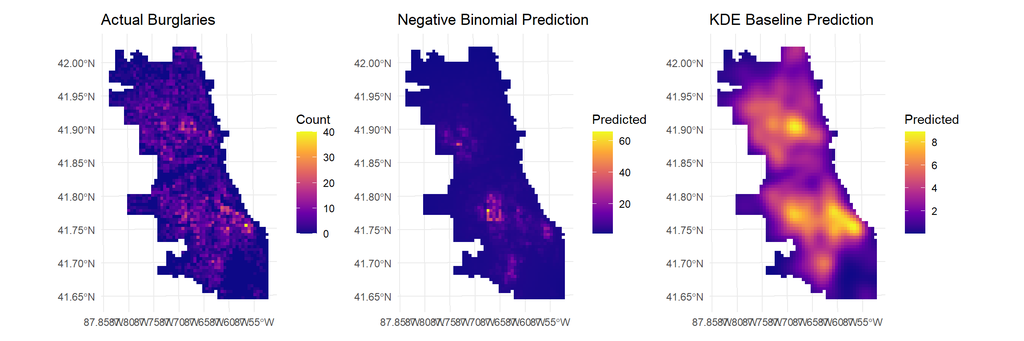

```r
p1 <- ggplot(fishnet_model) +
  geom_sf(aes(fill = burglary_count), color = NA) +
  scale_fill_viridis_c(option = "plasma") +
  labs(title = "Actual Burglaries", fill = "Count") +
  theme_minimal()

p2 <- ggplot(fishnet_model) +
  geom_sf(aes(fill = prediction_nb), color = NA) +
  scale_fill_viridis_c(option = "plasma") +
  labs(title = "Negative Binomial Prediction", fill = "Predicted") +
  theme_minimal()

p3 <- ggplot(fishnet_model) +
  geom_sf(aes(fill = prediction_kde), color = NA) +
  scale_fill_viridis_c(option = "plasma") +
  labs(title = "KDE Baseline Prediction", fill = "Predicted") +
  theme_minimal()

p1 + p2 + p3
```

**Interpretation**:

The Negative Binomial model captures some higher-risk areas, but its predictions appear more uneven and include stronger overprediction in a small number of cells, while the KDE baseline more closely follows the broader spatial concentration of burglaries across Chicago.

### 7. Compare model performance with KDE baseline

```r
comparison_table <- tibble(
  Model = c("Vacancy-Based Negative Binomial Model", "KDE Baseline"),
  MAE = c(
    mean(abs(fishnet_model$burglary_count - fishnet_model$prediction_nb), na.rm = TRUE),
    mean(abs(fishnet_model$burglary_count - fishnet_model$prediction_kde), na.rm = TRUE)
  ),
  RMSE = c(
    sqrt(mean((fishnet_model$burglary_count - fishnet_model$prediction_nb)^2, na.rm = TRUE)),
    sqrt(mean((fishnet_model$burglary_count - fishnet_model$prediction_kde)^2, na.rm = TRUE))
  )
)

knitr::kable(
  comparison_table,
  digits = 3,
  caption = "Comparison of Vacancy-Based Model and KDE Baseline"
)
```

Comparison of Vacancy-Based Model and KDE Baseline

| Model | MAE | RMSE |
| --- | --- | --- |
| Vacancy-Based Negative Binomial Model | 2.507 | 3.878 |
| KDE Baseline | 1.954 | 2.831 |

**Interpretation**:

The model comparison shows that the KDE baseline outperformed the vacancy-based Negative Binomial model.This means that the KDE approach predicted burglary counts more accurately overall and also had fewer large prediction errors.

### 8. Error Analysis

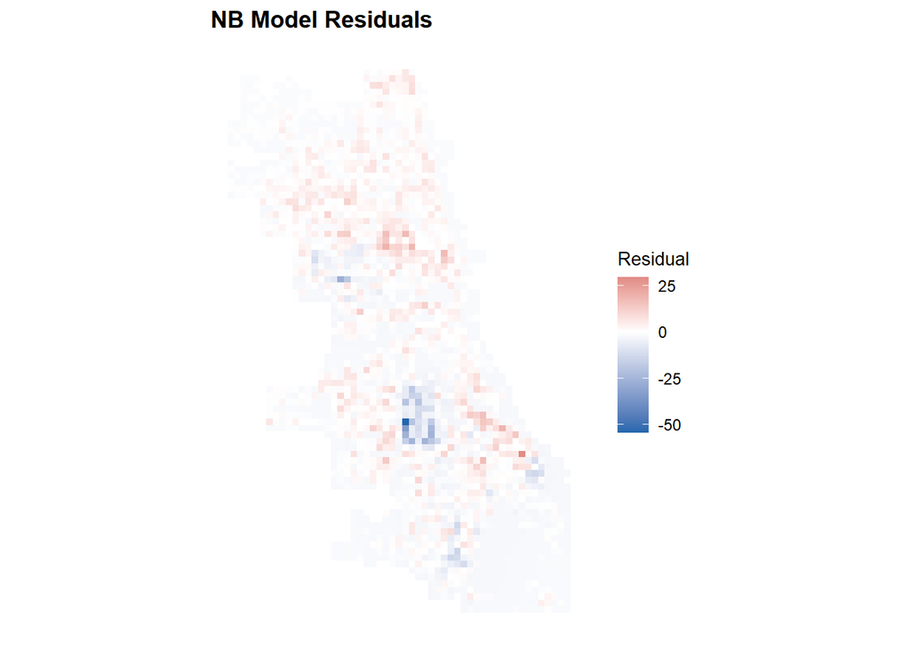

```r
fishnet_model <- fishnet_model |>
  mutate(
    residual_nb = burglary_count - prediction_nb,
    residual_kde = burglary_count - prediction_kde,
    abs_error_nb = abs(burglary_count - prediction_nb)
  )

ggplot(fishnet_model) +
  geom_sf(aes(fill = residual_nb), color = NA) +
  scale_fill_gradient2(
    low = "#2166ac",
    mid = "white",
    high = "#b2182b",
    midpoint = 0
  ) +
  labs(
    title = "NB Model Residuals",
    fill = "Residual"
  ) +
  coord_sf(datum = NA) +
  theme_minimal() +
  theme(
    axis.text = element_blank(),
    axis.title = element_blank(),
    panel.grid = element_blank(),
    plot.title = element_text(size = 13, face = "bold"),
    legend.position = "right",
    legend.title = element_text(size = 10),
    legend.text = element_text(size = 9)
  )
```

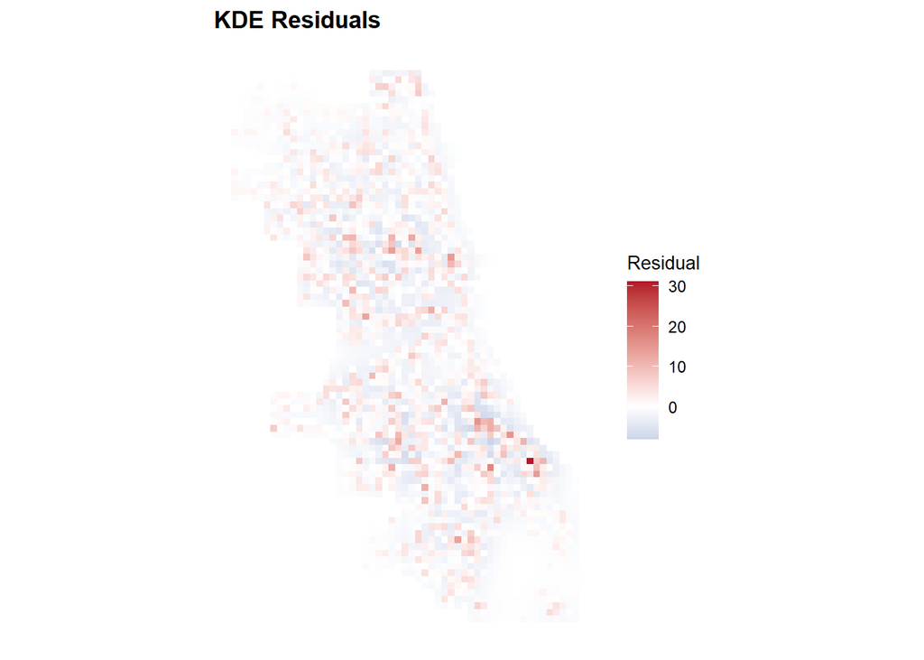

```r
ggplot(fishnet_model) +
  geom_sf(aes(fill = residual_kde), color = NA) +
  scale_fill_gradient2(
    low = "#2166ac",
    mid = "white",
    high = "#b2182b",
    midpoint = 0
  ) +
  labs(
    title = "KDE Residuals",
    fill = "Residual"
  ) +
  coord_sf(datum = NA) +
  theme_minimal() +
  theme(
    axis.text = element_blank(),
    axis.title = element_blank(),
    panel.grid = element_blank(),
    plot.title = element_text(size = 13, face = "bold"),
    legend.position = "right",
    legend.title = element_text(size = 10),
    legend.text = element_text(size = 9)
  )
```

**Interpretation**:

The residual maps show that both models still make spatially uneven prediction errors. In the NB residual map, most cells are close to zero, but there are still some blue and red clusters. This means the Negative Binomial model fits many areas reasonably well, but it still overpredicts in some places and underpredicts in others. The KDE residual map is more dominated by positive values, which suggests that KDE tends to underpredict burglary counts in many cells.